# Time Series and Forecasting Assignment

### Course: Time Series and forecasting methods

#### Program: MSc in Data Science (part-time)

- Student: **Perakis Georgios**
- Code: **DS3616014**
- Contact: **gperakis[at]aueb.gr**

## Assignment Description

The data you will have to analyze are in the eclass in the **excel data-assignment.xls** file. The **dependent variables** for which you will construct the models you are asked for, are the **returns** of four investment vechicles **(Y1, Y2, Y3, Y4)** for the period **1/1991 - 12/2005**.

The **independent variables** you will use in the models refer to **monthly** values/returns for the variables:

- x1 = RUS-Rf
- x2 = RUS (-1) -Rf (-1) lagged Russel index
- x3 = MXUS-Rf
- x4 = MEM- Rf
- x5 = SMB
- x6 = HML
- x7 = MOM
- x8 = SBGC-Rf
- x9 = SBWG-Rf
- x10 = LHY-Rf
- x11 = DEFSPR
- x12 = FRSI-Rf
- x13 = GSCI-Rf
- x14 = VIX

for the period **1/1991 - 12/2005**.

Analyze dependent variables based on data for the period 1/1991 - 12/2004 **[You will not use the data for the period 1/2005 - 12/2005]**:

1. Construct an appropriate **time series** model (AR, MA, ARMA).
2. Develop an appropriate **regression** model
   - In case of **autocorrelation** problem of **regression residuals**, correct the autocorrelation problem (using time series AR, MA, ARMA models).
   - In case of **heteroscedasticity** problem of **regression residuals**, correct the heteroskedasticity problem (using time-varying ARCH, GARCH models).
3. Write the models you have found at questions (1) - (2). Assess the **goodness of fit** of these models based on the **AIC and BIC** information criteria.
4. Based on the estimated models of questions (1) - (2), **construct forecasts** of the analyzed series for the period **1/2005 - 12/2005**, and **evaluate the forecasts** you have found by using two evaluation criteria:
   - the mean square prediction error
   - the Hit ratio (indicates the percentage of predictions that correctly evaluate the sign of the actual value of the dependent variable.)

Each student will have to analyze **two only dependent variables**

## Exercise 2:

### Develop an appropriate regression model

The constructed model will be of the form:

$$y_{t+1} = a + b_{1}* x_{1, t} + ... + b_{k}* x_{k, t} + e_{t + 1}$$

with $$e_{t + 1} \thicksim N(0, σ^2)$$

### Load Libraries

```r
# loads the library urca, which contains the command ur.df()
# and applies Unit-Root Testing based on Dickey-Fuller test
# install.packages(c('fGarch', 'urca','tseries','MASS'))
library(urca)
library(tseries)
library(MASS)
library(fGarch)
```

```r
# Importing data into R can be carried out in various ways. Below, the command read.table is used:
data_all = read.table('/home/socital1/Desktop/george/AUEB/TimeSeries/time_series_in_r/Data-Assignment-Feb-2018.txt')
```

```r
xdata_cols <- c('V5','V6', 'V7','V8','V9','V10','V11','V12','V13','V14','V15','V16','V17','V18')

xdata <- data_all[c(xdata_cols)]
```

```r
head(xdata)
```

| V5 | V6 | V7 | V8 | V9 | V10 | V11 | V12 | V13 | V14 | V15 | V16 | V17 | V18 |
| --- | --- | --- | --- | --- | --- | --- | --- | --- | --- | --- | --- | --- | --- |
| 0.04568 | 0.01745 | 0.02313 | 0.07273 | 0.0389 | -0.0181 | -0.0946 | 0.00575 | 0.01937 | 0.01868 | 0.0001 | 0.00004 | -0.10389 | -0.0547 |
| 0.06346 | 0.04568 | 0.09344 | 0.13201 | 0.0397 | -0.0056 | -0.1147 | 0.00144 | -0.00486 | 0.10639 | -0.0014 | -0.01039 | 0.00866 | 0.0032 |
| 0.02225 | 0.06346 | -0.06591 | 0.03187 | 0.0395 | -0.0124 | -0.0407 | 0.00253 | -0.04193 | 0.02621 | -0.0024 | 0.03228 | 0.03201 | -0.0435 |
| -0.00581 | 0.02225 | 0.00371 | -0.00174 | 0.0037 | 0.0170 | -0.0224 | 0.00790 | 0.01053 | 0.01619 | -0.0008 | 0.01107 | 0.01764 | 0.0136 |
| 0.03258 | -0.00581 | 0.00577 | 0.06795 | -0.0037 | -0.0052 | 0.0282 | -0.00023 | -0.00601 | -0.00780 | -0.0011 | 0.00235 | -0.00524 | -0.0231 |
| -0.05360 | 0.03258 | -0.07982 | -0.04322 | 0.0006 | 0.0102 | 0.0010 | -0.00499 | -0.01526 | 0.01826 | -0.0011 | 0.01085 | -0.02869 | 0.0362 |

###### Let create a time series object using the function “ts” from a vector - single time-series or a matrix - multivariate time-series. The data consist of the Y2 monthly returns from 1/1991 - 12/2004,

```r
y2 <- data_all$V2

j2 = ts(y2, frequency=12, start = c(1991, 1), end = c(2004, 12))
xfactors=ts(xdata, frequency=12,  start = c(1991, 1), end = c(2004, 12))
```

```r
train_data = data_all[1: 168,]
test_data = data_all[169:180,]
```

```r
attach(train_data)
```

#### Performing Stepwise Linear Regression will all the parameters, in order to find the best model with the lower AIC

```r
fitnull <- lm(V2 ~ 1)

stepSR <- step(fitnull,
               scope=list(lower = ~ 1,
                          upper = ~ V5 + V6 + V7 + V8 + V9 + V10 + V11 + V12 + V13 + V14 + V15 + V16 + V17 + V18),
               direction="both",
               data=train_data)

stepSR$anova
```

```
Start:  AIC=-1526.71
V2 ~ 1

       Df Sum of Sq      RSS     AIC
+ V8    1 0.0037046 0.015065 -1561.7
+ V14   1 0.0031353 0.015634 -1555.4
+ V5    1 0.0026949 0.016075 -1550.8
+ V7    1 0.0021734 0.016596 -1545.4
+ V9    1 0.0020838 0.016686 -1544.5
+ V18   1 0.0020766 0.016693 -1544.4
+ V11   1 0.0013439 0.017426 -1537.2
+ V6    1 0.0011200 0.017650 -1535.0
+ V15   1 0.0004779 0.018292 -1529.0
<none>              0.018770 -1526.7
+ V17   1 0.0002148 0.018555 -1526.7
+ V13   1 0.0000655 0.018704 -1525.3
+ V12   1 0.0000616 0.018708 -1525.3
+ V16   1 0.0000174 0.018752 -1524.9
+ V10   1 0.0000069 0.018763 -1524.8

Step:  AIC=-1561.65
V2 ~ V8

       Df Sum of Sq      RSS     AIC
+ V14   1 0.0009047 0.014160 -1570.0
+ V6    1 0.0007738 0.014291 -1568.5
+ V9    1 0.0006394 0.014426 -1566.9
+ V11   1 0.0003698 0.014695 -1563.8
<none>              0.015065 -1561.7
+ V18   1 0.0001666 0.014899 -1561.5
+ V5    1 0.0001622 0.014903 -1561.5
+ V12   1 0.0001572 0.014908 -1561.4
+ V17   1 0.0001096 0.014956 -1560.9
+ V7    1 0.0000995 0.014966 -1560.8
+ V16   1 0.0000934 0.014972 -1560.7
+ V10   1 0.0000679 0.014997 -1560.4
+ V15   1 0.0000389 0.015026 -1560.1
+ V13   1 0.0000282 0.015037 -1560.0
- V8    1 0.0037046 0.018770 -1526.7

```

[output cut: 84 more lines]

```
<none>               0.012941 -1577.2
+ V17   1 0.00013238 0.012808 -1576.9
- V14   1 0.00017716 0.013118 -1576.9
+ V16   1 0.00011265 0.012828 -1576.7
+ V13   1 0.00009166 0.012849 -1576.4
- V12   1 0.00022252 0.013163 -1576.3
+ V11   1 0.00007336 0.012867 -1576.1
+ V10   1 0.00006313 0.012877 -1576.0
+ V15   1 0.00004378 0.012897 -1575.8
+ V5    1 0.00003603 0.012904 -1575.7
+ V7    1 0.00001627 0.012924 -1575.4
- V9    1 0.00031770 0.013258 -1575.1
- V18   1 0.00036076 0.013301 -1574.6
- V8    1 0.00047838 0.013419 -1573.1
- V6    1 0.00060902 0.013550 -1571.5
```

| Step | Df | Deviance | Resid. Df | Resid. Dev | AIC |
| --- | --- | --- | --- | --- | --- |
|  | NA | NA | 167 | 0.01876969 | -1526.712 |
| + V8 | -1 | 0.0037045937 | 166 | 0.01506510 | -1561.649 |
| + V14 | -1 | 0.0009047015 | 165 | 0.01416040 | -1570.053 |
| + V6 | -1 | 0.0004733591 | 164 | 0.01368704 | -1573.765 |
| + V18 | -1 | 0.0002871466 | 163 | 0.01339989 | -1575.327 |
| + V9 | -1 | 0.0002368643 | 162 | 0.01316303 | -1576.324 |
| + V12 | -1 | 0.0002225202 | 161 | 0.01294051 | -1577.188 |

```r
summary(stepSR)
```

```
Call:
lm(formula = V2 ~ V8 + V14 + V6 + V18 + V9 + V12)

Residuals:
      Min        1Q    Median        3Q       Max
-0.038894 -0.004629 -0.000243  0.005318  0.035395

Coefficients:
              Estimate Std. Error t value Pr(>|t|)
(Intercept)  0.0056275  0.0007347   7.660 1.64e-12 ***
V8           0.0345018  0.0141422   2.440  0.01579 *
V14          0.0491334  0.0330941   1.485  0.13959
V6           0.0500754  0.0181916   2.753  0.00659 **
V18         -0.0516948  0.0244005  -2.119  0.03566 *
V9           0.0454971  0.0228842   1.988  0.04849 *
V12          0.0967278  0.0581339   1.664  0.09808 .
---
Signif. codes:  0 ‘***’ 0.001 ‘**’ 0.01 ‘*’ 0.05 ‘.’ 0.1 ‘ ’ 1

Residual standard error: 0.008965 on 161 degrees of freedom
Multiple R-squared:  0.3106,	Adjusted R-squared:  0.2849
F-statistic: 12.09 on 6 and 161 DF,  p-value: 3.414e-11
```

```r
detach(train_data)
```

### We'll now run a diagnostic check for the residuals of the fitted regression model

```r
stepSRresidualsTS <- ts(stepSR$residuals,
                        frequency=12,
                        start = c(1991,1),
                        end = c(2004, 12))
stepSRresidualsTS
```

```
               Jan           Feb           Mar           Apr           May
1991  5.497876e-03  6.353122e-03  6.196820e-03  5.543486e-03 -6.031238e-03
1992  3.539504e-02  1.467928e-02 -1.672466e-02  1.647635e-02  7.836771e-03
1993  1.150221e-02 -3.899597e-05  2.709609e-02  1.433624e-02  1.747801e-02
1994  1.280124e-02 -5.671607e-04  8.222096e-03 -1.024676e-02 -1.059850e-02
1995  5.230047e-03 -1.717158e-03 -4.774483e-03  9.011491e-04 -7.209761e-03
1996  2.385722e-03  8.387227e-03  3.199949e-03  6.971117e-03  6.642377e-03
1997  2.641407e-03 -7.416434e-04 -1.162323e-02  6.616856e-03  1.386806e-03
1998  9.263609e-03  9.542573e-05  5.125235e-03  6.513591e-03 -1.924359e-04
1999  1.438295e-02 -3.681173e-03 -6.535911e-03  1.347913e-02  2.008067e-03
2000  6.051300e-03 -3.384589e-03  1.396502e-02  8.844427e-03  2.543574e-03
2001 -6.934618e-03  5.526281e-03  4.382591e-03 -5.264611e-04 -7.580090e-03
2002 -1.599437e-03 -5.477258e-03 -4.553677e-03 -5.109866e-03 -1.369935e-03
2003  5.258051e-03  7.089600e-04  1.315638e-03 -4.222328e-03 -8.448209e-03
2004 -7.111321e-04 -4.510928e-03 -3.320245e-03 -2.879626e-03 -6.892182e-03
```

[output cut: 30 more lines]

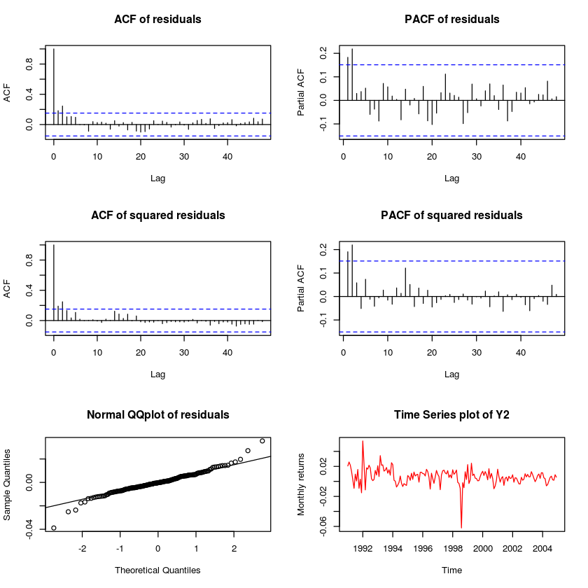

```r
par(mfrow=c(3,2))

# set up the graphics
acf(ts(stepSRresidualsTS,freq=1), 48, main="ACF of residuals")
pacf(ts(stepSRresidualsTS,freq=1), 48, main="PACF of residuals")
acf(ts(stepSRresidualsTS^2,freq=1), 48, main="ACF of squared residuals")
pacf(ts(stepSRresidualsTS^2,freq=1), 48, main="PACF of squared residuals")
qqnorm(stepSRresidualsTS,main="Normal QQplot of residuals")
qqline(stepSRresidualsTS)
plot(j2, type="l", col='red', lwd=1, main="Time Series plot of Y2", ylab="Monthly returns")
```

### Based on the residual plots presented above:

- From the ACF and PACF of the residuals, it seems that the assumptions with respect to them are **not** satisfied:
  - **MA(2) (1,2, lags)** and **AR(2) (1,2 lags)** must be implemented in the residuals of the stepwise regression model.
- From the PACF fo the **squared residuals** it seems that there is an **heteroskedastisity** issue.
  - We'll try to fix this by implementing a ARCH and GARCH models in the residuals
- From the Normal QQPlot of residuals several points are off the line. So we assume non normality.

From the lower right plot of the return series we observe that the volatility of the return series is not constant over time. There is evidence of volatility clustering phenomenon, since there are periods of high and low volatility.

## Models

### AR(2) for lags: 1, 2

```r
ar2fit <- arima(stepSRresidualsTS, order=c(2,0,0))
ar2fit
```

```
Call:
arima(x = stepSRresidualsTS, order = c(2, 0, 0))

Coefficients:
        ar1    ar2  intercept
      0.143  0.218      0.000
s.e.  0.075  0.075      0.001

sigma^2 estimated as 7.084e-05:  log likelihood = 564.18,  aic = -1120.35
```

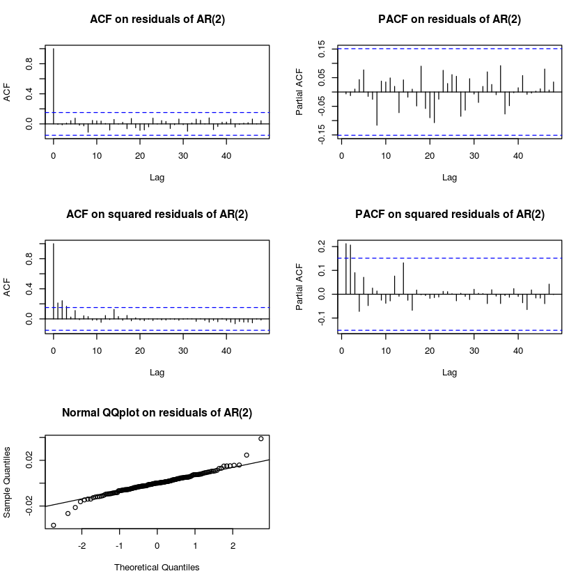

```r
par(mfrow=c(3,2))
ar2fit_residualsTS <- ts(ar2fit$residuals, frequency=12, start = c(1991, 1), end = c(2004, 12))

# set up the graphics
acf(ts(ar2fit_residualsTS,freq=1), 48, main="ACF on residuals of AR(2)")
pacf(ts(ar2fit_residualsTS,freq=1), 48, main="PACF on residuals of AR(2)")
acf(ts(ar2fit_residualsTS^2,freq=1), 48, main="ACF on squared residuals of AR(2)")
pacf(ts(ar2fit_residualsTS^2,freq=1), 48, main="PACF on squared residuals of AR(2)")
qqnorm(ar2fit_residualsTS,main="Normal QQplot on residuals of AR(2)")
qqline(ar2fit_residualsTS)
```

```r
Box.test(ar2fit_residualsTS, lag=12, type="Ljung")
Box.test(ar2fit_residualsTS^2, lag=12, type="Ljung")
```

```
	Box-Ljung test

data:  ar2fit_residualsTS
X-squared = 4.6845, df = 12, p-value = 0.9677
```

```
	Box-Ljung test

data:  ar2fit_residualsTS^2
X-squared = 26.221, df = 12, p-value = 0.009986
```

### Moving Average Model: MA(2) (1, 2 lags)

```r
ma2fit <- arima(stepSRresidualsTS, order=c(0,0,2))
ma2fit
```

```
Call:
arima(x = stepSRresidualsTS, order = c(0, 0, 2))

Coefficients:
         ma1     ma2  intercept
      0.1368  0.2085      0e+00
s.e.  0.0760  0.0712      9e-04

sigma^2 estimated as 7.164e-05:  log likelihood = 563.26,  aic = -1118.51
```

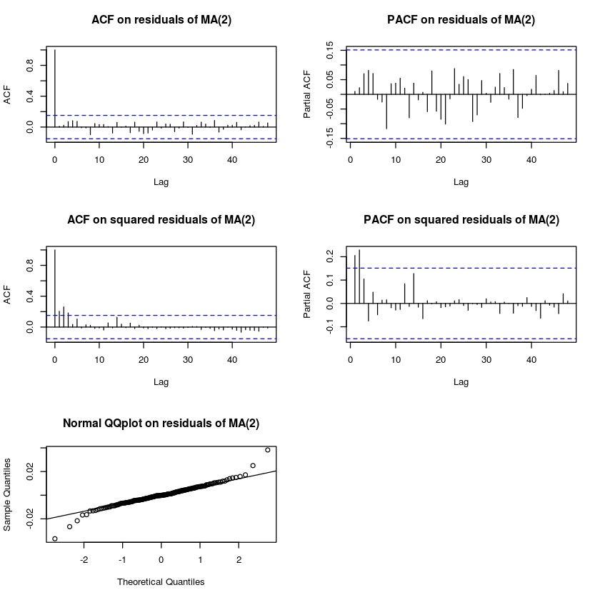

```r
par(mfrow=c(3,2))
ma2fit_residualsTS <- ts(ma2fit$residuals, frequency=12, start = c(1991, 1), end = c(2004, 12))

# set up the graphics
acf(ts(ma2fit_residualsTS,freq=1), 48, main="ACF on residuals of MA(2)")
pacf(ts(ma2fit_residualsTS,freq=1), 48, main="PACF on residuals of MA(2)")
acf(ts(ma2fit_residualsTS^2,freq=1), 48, main="ACF on squared residuals of MA(2)")
pacf(ts(ma2fit_residualsTS^2,freq=1), 48, main="PACF on squared residuals of MA(2)")
qqnorm(ma2fit_residualsTS,main="Normal QQplot on residuals of MA(2)")
qqline(ma2fit_residualsTS)
```

```r
Box.test(ma2fit_residualsTS, lag=12, type="Ljung")
Box.test(ma2fit_residualsTS^2, lag=12, type="Ljung")
```

```
	Box-Ljung test

data:  ma2fit_residualsTS
X-squared = 5.6701, df = 12, p-value = 0.9318
```

```
	Box-Ljung test

data:  ma2fit_residualsTS^2
X-squared = 28.049, df = 12, p-value = 0.005441
```

### ARMA(2, 2)

```r
arma22fit <- arima(stepSRresidualsTS, order=c(2, 0,2))
arma22fit
```

```
Call:
arima(x = stepSRresidualsTS, order = c(2, 0, 2))

Coefficients:
         ar1     ar2      ma1      ma2  intercept
      0.2244  0.3032  -0.0912  -0.1081     0.0000
s.e.  0.4039  0.3144   0.4151   0.2791     0.0011

sigma^2 estimated as 7.067e-05:  log likelihood = 564.37,  aic = -1116.75
```

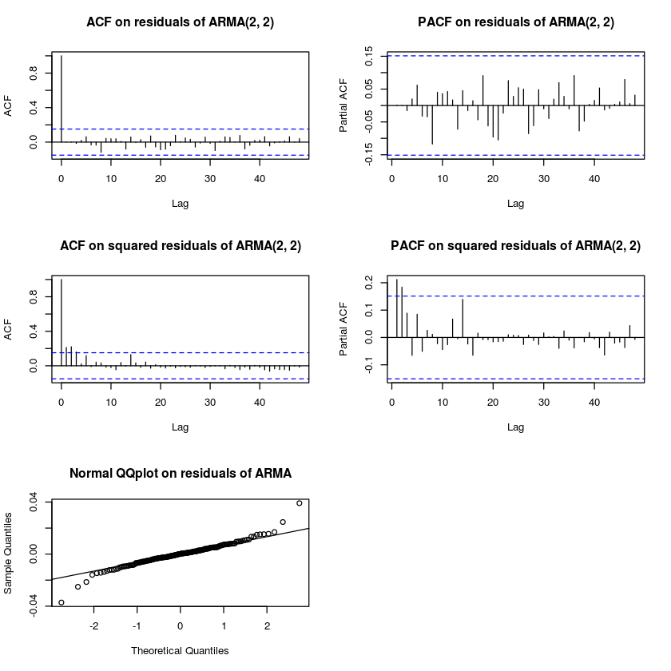

```r
par(mfrow=c(3,2))
arma22fit_residualsTS <- ts(arma22fit$residuals, frequency=12, start = c(1991, 1), end = c(2004, 12))

# set up the graphics
acf(ts(arma22fit_residualsTS,freq=1), 48, main="ACF on residuals of ARMA(2, 2)")
pacf(ts(arma22fit_residualsTS,freq=1), 48, main="PACF on residuals of ARMA(2, 2)")
acf(ts(arma22fit_residualsTS^2,freq=1), 48, main="ACF on squared residuals of ARMA(2, 2)")
pacf(ts(arma22fit_residualsTS^2,freq=1), 48, main="PACF on squared residuals of ARMA(2, 2)")
qqnorm(arma22fit_residualsTS, main="Normal QQplot on residuals of ARMA")
qqline(arma22fit_residualsTS)
```

```r
Box.test(arma22fit_residualsTS, lag=12, type="Ljung")
Box.test(arma22fit_residualsTS^2, lag=12, type="Ljung")
```

```
	Box-Ljung test

data:  arma22fit_residualsTS
X-squared = 4.5651, df = 12, p-value = 0.971
```

```
	Box-Ljung test

data:  arma22fit_residualsTS^2
X-squared = 24.199, df = 12, p-value = 0.01911
```

### Based on the residual plots and the Box Tests of the 3 different models presented above:

- From the ACF and PACF of the residuals:
  - **AR(2)**: It seems that the assumptions with respect to them are satisfied
  - **MA(2)**: It seems that the assumptions with respect to them are satisfied
  - **ARMA(2,2)**: It seems that the assumptions with respect to them are satisfied
- From the PACF fo the **squared** residuals:
  - **Restricted AR**: It seems that the assumptions regarding homoskedasticity are **not** satisfied
  - **Restricted MA**: It seems that the assumptions regarding homoskedasticity are **not** satisfied
  - **Restricted ARMA**: It seems that the assumptions regarding homoskedasticity are **not** satisfied
- From the Normal QQPlot of residuals **for all 3 models** normality is **rejected**!!

Summarizing we have the following:

- AR(2):
  - Variance: **7.084e-05**
  - AIC: **-1120.35**
- MA(2):
  - Variance: **7.164e-05**
  - AIC: **-1118.51**
- ARMA(2, 2)
  - Variance: **7.067e-05**
  - AIC: **-1116.75**

### Conclusion:

- The model with the lowest variance and lower AIC score is the best.
- Here, **AR(2)** has the smallest AIC and the second smallest variance. Thus, in my belief, it's the model that best fits the data.

## Heteroskedasticity

```r
# First, we will fit an ARCH(1) model:
m1arch <- garchFit(~garch(1,0), data=stepSR$residuals, trace=F)
# trace = F reduces the summary
summary(m1arch)
```

```
Title:
 GARCH Modelling

Call:
 garchFit(formula = ~garch(1, 0), data = stepSR$residuals, trace = F)

Mean and Variance Equation:
 data ~ garch(1, 0)
<environment: 0x6d53bc8>
 [data = stepSR$residuals]

Conditional Distribution:
 norm

Coefficient(s):
         mu        omega       alpha1
-9.7851e-19   5.5408e-05   2.8575e-01

Std. Errors:
 based on Hessian

Error Analysis:
         Estimate  Std. Error  t value Pr(>|t|)
mu     -9.785e-19   6.676e-04    0.000   1.0000
omega   5.541e-05   7.814e-06    7.091 1.33e-12 ***
alpha1  2.857e-01   1.192e-01    2.397   0.0165 *
---
Signif. codes:  0 ‘***’ 0.001 ‘**’ 0.01 ‘*’ 0.05 ‘.’ 0.1 ‘ ’ 1

Log Likelihood:
 564.1567    normalized:  3.358075

Description:
 Mon Mar  5 12:53:21 2018 by user:


Standardised Residuals Tests:
                                Statistic p-Value
 Jarque-Bera Test   R    Chi^2  36.80611  1.017781e-08
 Shapiro-Wilk Test  R    W      0.9700936 0.001085258
 Ljung-Box Test     R    Q(10)  24.07964  0.007391775
 Ljung-Box Test     R    Q(15)  27.1369   0.02764057
 Ljung-Box Test     R    Q(20)  34.45044  0.02323433
 Ljung-Box Test     R^2  Q(10)  14.83792  0.1380837
 Ljung-Box Test     R^2  Q(15)  19.88399  0.1764282
 Ljung-Box Test     R^2  Q(20)  27.47667  0.1223781
 LM Arch Test       R    TR^2   14.8716   0.2485335

Information Criterion Statistics:
      AIC       BIC       SIC      HQIC
-6.680436 -6.624651 -6.681059 -6.657796
```

We obtain the parameter estimates, the corresponding standard errors, the t-statistics and the associated p-values, in order to examine the statistical significance of the model parameters.

The ARCH(1) model is written:

$$y_{t} = μ + e_{t} , $$ $$e_{t} = σ_{t}*v_{t} \thicksim N(0,1), $$ $$σ^2_{t} = a_{0} + a_{1}*e^2_{t-1} $$

Thus, the estimated ARCH(1) model is: $$y_{t} = -9.7851 * 10^{-19} + e_{t} , $$ $$e_{t} = σ_{t}*v_{t} \thicksim N(0,1), $$ $$σ^2_{t} = 5.5408 * 10^{-5} + 2.8575* 10^{-1}*e^2_{t-1} $$

There are different diagnostic tests outlined in the aformentioned summary, performed on the residuals $R$ and/or the squared residuals $R^2$.

The **Jarque-Bera** and the **Shapiro-Wilk** tests are used in order to examine the normality assumption of the model residuals. It seems that the null hypothesis of normality (p-values 1.017781e-08 and 0.001085258) **is rejected**, i.e. there is evidence of **non normality** of residuals.

Most of the remaining tests are based on the Ljung-Box Q-statistic to examine the autocorrelation of the residuals and/or the squared residuals. The results indicate that there **exists autocorrelation** in the **residuals** series. On the contrary the tests indicate **no autocorrelation in the squared residuals**.

That is, the ARCH(1) model did not capture adequately the time-varying characteristics of the return series.

```r
predict(m1arch, 6)
```

| meanForecast | meanError | standardDeviation |
| --- | --- | --- |
| -9.785095e-19 | 0.007830716 | 0.007830716 |
| -9.785095e-19 | 0.008539892 | 0.008539892 |
| -9.785095e-19 | 0.008731963 | 0.008731963 |
| -9.785095e-19 | 0.008786076 | 0.008786076 |
| -9.785095e-19 | 0.008801477 | 0.008801477 |
| -9.785095e-19 | 0.008805873 | 0.008805873 |

#### Student t ARCH model

```r
m1arch_student=garchFit(~garch(1,0),data=stepSR$residuals, cond.dist="std",trace=F)
summary(m1arch_student)
```

```
Title:
 GARCH Modelling

Call:
 garchFit(formula = ~garch(1, 0), data = stepSR$residuals, cond.dist = "std",
    trace = F)

Mean and Variance Equation:
 data ~ garch(1, 0)
<environment: 0x552d758>
 [data = stepSR$residuals]

Conditional Distribution:
 std

Coefficient(s):
         mu        omega       alpha1        shape
-9.7851e-19   5.7074e-05   2.5579e-01   5.3200e+00

Std. Errors:
 based on Hessian

Error Analysis:
         Estimate  Std. Error  t value Pr(>|t|)
mu     -9.785e-19   6.108e-04    0.000  1.00000
omega   5.707e-05   1.214e-05    4.701 2.59e-06 ***
alpha1  2.558e-01   1.487e-01    1.721  0.08531 .
shape   5.320e+00   2.037e+00    2.612  0.00901 **
---
Signif. codes:  0 ‘***’ 0.001 ‘**’ 0.01 ‘*’ 0.05 ‘.’ 0.1 ‘ ’ 1

Log Likelihood:
 570.4638    normalized:  3.395618

Description:
 Mon Mar  5 12:53:21 2018 by user:


Standardised Residuals Tests:
                                Statistic p-Value
 Jarque-Bera Test   R    Chi^2  37.57245  6.938177e-09
 Shapiro-Wilk Test  R    W      0.9702509 0.001129714
 Ljung-Box Test     R    Q(10)  24.10863  0.007317222
 Ljung-Box Test     R    Q(15)  26.99237  0.02879858
 Ljung-Box Test     R    Q(20)  34.11107  0.02538307
 Ljung-Box Test     R^2  Q(10)  15.24501  0.1233814
 Ljung-Box Test     R^2  Q(15)  19.78641  0.1802804
 Ljung-Box Test     R^2  Q(20)  26.97598  0.1359411
 LM Arch Test       R    TR^2   15.0083   0.2409829

Information Criterion Statistics:
      AIC       BIC       SIC      HQIC
-6.743617 -6.669237 -6.744716 -6.713430
```

The ARCH(1) model based on **Student-t** errors is:

$$y_{t} = μ + e_{t} , $$ $$e_{t} = σ_{t}*v_{t}, v_{t}\thicksim Student-t_{5.32}, $$ $$σ^2_{t} = a_{0} + a_{1}*e^2_{t-1} $$

Thus, the estimated ARCH(1) model is: $$y_{t} = -9.7851 * 10^{-19} + e_{t} , $$ $$e_{t} = σ_{t}*v_{t}, v_{t}\thicksim Student-t_{5.32}, $$ $$σ^2_{t} = 5.7074 * 10^{-5} + 2.5579* 10^{-1}*e^2_{t-1} $$

There are different diagnostic tests outlined in the aformentioned summary, performed on the residuals $R$ and/or the squared residuals $R^2$.

The **Jarque-Bera** and the **Shapiro-Wilk** tests are used in order to examine the normality assumption of the model residuals. It seems that the null hypothesis of normality (p values 6.938177e-09 and 0.001129714) **is rejected**, i.e. there is evidence of **non normality** of residuals.

Most of the remaining tests are based on the Ljung-Box Q-statistic to examine the autocorrelation of the residuals and/or the squared residuals. The results indicate that there **exists autocorrelation** in the **residuals** series.

That is, the student-t ARCH(1) model did not capture adequately the time-varying characteristics of the return series.

### GARCH Models

```r
m2garch=garchFit(~garch(1,1), data=stepSR$residuals,trace=F)
summary(m2garch)
```

```
Title:
 GARCH Modelling

Call:
 garchFit(formula = ~garch(1, 1), data = stepSR$residuals, trace = F)

Mean and Variance Equation:
 data ~ garch(1, 1)
<environment: 0x67b09e8>
 [data = stepSR$residuals]

Conditional Distribution:
 norm

Coefficient(s):
         mu        omega       alpha1        beta1
-9.7851e-19   1.6039e-05   3.6567e-01   4.5820e-01

Std. Errors:
 based on Hessian

Error Analysis:
         Estimate  Std. Error  t value Pr(>|t|)
mu     -9.785e-19   6.917e-04    0.000 1.000000
omega   1.604e-05   7.418e-06    2.162 0.030610 *
alpha1  3.657e-01   1.261e-01    2.900 0.003732 **
beta1   4.582e-01   1.362e-01    3.365 0.000765 ***
---
Signif. codes:  0 ‘***’ 0.001 ‘**’ 0.01 ‘*’ 0.05 ‘.’ 0.1 ‘ ’ 1

Log Likelihood:
 572.0243    normalized:  3.404906

Description:
 Mon Mar  5 12:53:21 2018 by user:


Standardised Residuals Tests:
                                Statistic p-Value
 Jarque-Bera Test   R    Chi^2  24.94429  3.831909e-06
 Shapiro-Wilk Test  R    W      0.9797822 0.01488866
 Ljung-Box Test     R    Q(10)  20.44088  0.0253479
 Ljung-Box Test     R    Q(15)  23.09888  0.08206291
 Ljung-Box Test     R    Q(20)  31.108    0.05378078
 Ljung-Box Test     R^2  Q(10)  1.571626  0.9986944
 Ljung-Box Test     R^2  Q(15)  4.240965  0.9968351
 Ljung-Box Test     R^2  Q(20)  13.53732  0.8531592
 LM Arch Test       R    TR^2   2.50297   0.9981511

Information Criterion Statistics:
      AIC       BIC       SIC      HQIC
-6.762194 -6.687814 -6.763293 -6.732007
```

The GARCH(1, 1) model is written:

$$y_{t} = μ + e_{t} , $$ $$e_{t} = σ_{t}*v_{t}, v_{t}\thicksim N(0,1), $$ $$σ^2_{t} = a_{0} + a_{1}*e^2_{t-1} + b_{1}*σ^2_{t-1} $$

Thus, the estimated GARCH(1, 1) model is: $$y_{t} = -9.7851* 10^{-19} + e_{t} , $$ $$e_{t} = σ_{t}*v_{t} \thicksim N(0,1), $$ $$σ^2_{t} = 1.6039 * 10^{-5} + 3.6567*10^{-1}e^2_{t-1} + 4.5820* 10^{-1}*σ^2_{t-1} $$

There are different diagnostic tests outlined in the aformentioned summary, performed on the residuals $R$ and/or the squared residuals $R^2$.

The **Jarque-Bera** and the **Shapiro-Wilk** tests are used in order to examine the normality assumption of the model residuals.

It seems that the null hypothesis of normality (p-values 3.831909e-06 and 0.01488866) **is rejected**, i.e. there is evidence of **non normality** of residuals.

Most of the remaining tests are based on the Ljung-Box Q-statistic to examine the autocorrelation of the residuals and/or the squared residuals.

The results indicate that there **exists some autocorrelation** in the **residuals** series.

On the contrary the tests indicate **no autocorrelation in the squared residuals**.

That is, the GARCH(1, 1) model did not capture adequately the time-varying characteristics of the return series.

### Combined ARMA + GARCH Model

```r
arma11_garch11fit <- garchFit(formula= ~arma(1,1) + garch(1,1),
                              data=stepSR$residuals,
                              trace=F)
summary(arma11_garch11fit)
```

```
Title:
 GARCH Modelling

Call:
 garchFit(formula = ~arma(1, 1) + garch(1, 1), data = stepSR$residuals,
    trace = F)

Mean and Variance Equation:
 data ~ arma(1, 1) + garch(1, 1)
<environment: 0x5929da8>
 [data = stepSR$residuals]

Conditional Distribution:
 norm

Coefficient(s):
         mu          ar1          ma1        omega       alpha1        beta1
 9.7851e-19   7.3118e-01  -4.2349e-01   1.3492e-05   4.2455e-01   4.2733e-01

Std. Errors:
 based on Hessian

Error Analysis:
         Estimate  Std. Error  t value Pr(>|t|)
mu      9.785e-19   2.917e-04    0.000 1.000000
ar1     7.312e-01   1.099e-01    6.650 2.93e-11 ***
ma1    -4.235e-01   1.570e-01   -2.698 0.006973 **
omega   1.349e-05   5.134e-06    2.628 0.008581 **
alpha1  4.245e-01   1.285e-01    3.305 0.000950 ***
beta1   4.273e-01   1.158e-01    3.691 0.000223 ***
---
Signif. codes:  0 ‘***’ 0.001 ‘**’ 0.01 ‘*’ 0.05 ‘.’ 0.1 ‘ ’ 1

Log Likelihood:
 583.6751    normalized:  3.474257

Description:
 Mon Mar  5 12:53:22 2018 by user:


Standardised Residuals Tests:
                                Statistic p-Value
 Jarque-Bera Test   R    Chi^2  10.11685  0.00635555
 Shapiro-Wilk Test  R    W      0.9876706 0.1479702
 Ljung-Box Test     R    Q(10)  3.11955   0.9784689
 Ljung-Box Test     R    Q(15)  6.727952  0.9647638
 Ljung-Box Test     R    Q(20)  14.17181  0.8216788
 Ljung-Box Test     R^2  Q(10)  2.129495  0.9952478
 Ljung-Box Test     R^2  Q(15)  5.605979  0.9856339
 Ljung-Box Test     R^2  Q(20)  13.03526  0.8758659
 LM Arch Test       R    TR^2   3.737421  0.987722

Information Criterion Statistics:
      AIC       BIC       SIC      HQIC
-6.877084 -6.765514 -6.879520 -6.831804
```

There are different diagnostic tests outlined in the aformentioned summary, performed on the residuals $R$ and/or the squared residuals $R^2$.

The **Jarque-Bera** and the **Shapiro-Wilk** tests are used in order to examine the normality assumption of the model residuals.

Most of the remaining tests are based on the Ljung-Box Q-statistic to examine the autocorrelation of the residuals and/or the squared residuals.

The results indicate that there is **no autocorrelation** in the **residuals** series.

Also, the tests indicate **no autocorrelation in the squared residuals**.

That is, **ARMA(1,1) + GARCH(1,1)** model **did capture** adequately the time-varying characteristics of the return series.

### Forecast and Evaluation

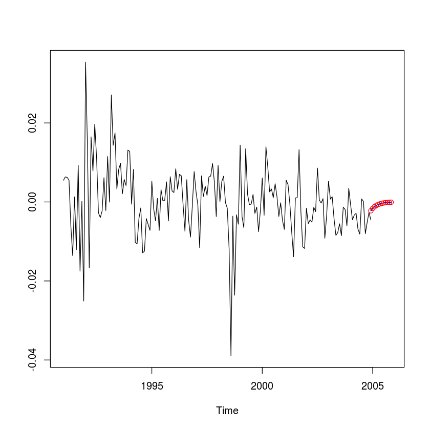

```r
forecast <- predict(arma11_garch11fit, 12)

# plot of forecasts with 1 standard error
par(mfrow=c(1,1))
UL <- forecast$meanForecast + forecast$meanError
LL <- forecast$meanForecast - forecast$meanError

predTS <- ts(forecast$meanForecast, frequency=12, start = c(2004, 12))
UL_TS <- ts(forecast$meanForecast, frequency=12, start = c(2004, 12))
LL_TS <- ts(forecast$meanForecast, frequency=12, start = c(2004, 12))

min_x <- min(stepSRresidualsTS, LL)
max_x <- max(stepSRresidualsTS, UL)

ts.plot(stepSRresidualsTS, predTS)
lines(predTS, col="red", type="o")
lines(UL_TS, col="blue", lty="dashed")
lines(LL_TS, col="blue", lty="dashed")
```

### Mean Squared Error

```r
library(hydroGOF)
MSE <- mse(forecast$meanForecast, forecast$meanError)
MSE
```

8.12530798552793e-05

$$MSE = 8.125* 10^{-5}$$